# R语言数据清洗与预处理

小天使格礼

# 前言

数据清洗与预处理是数据分析中最重要但也最耗时的环节。据统计，数据科学家约80%的时间都花在数据清洗上。本教程将系统介绍R语言中数据清洗与预处理的各项技术，帮助你高效地处理各种数据问题。

本教程涵盖以下内容：

| 章节 | 主题 | 核心内容 |
| --- | --- | --- |
| 第一章 | 数据探索与概览 | 了解数据的基本情况 |
| 第二章 | 缺失值处理 | 识别和处理缺失数据 |
| 第三章 | 重复值与异常值处理 | 数据质量问题解决 |
| 第四章 | 数据类型转换与变量重编码 | 数据格式规范化 |
| 第五章 | 数据筛选与排序 | 数据子集选择 |
| 第六章 | 数据变换与计算 | 创建新变量和汇总统计 |
| 第七章 | 数据合并与连接 | 多数据源整合 |
| 第八章 | 数据重塑 | 长宽格式转换 |
| 第九章 | 字符与日期处理 | 特殊数据类型处理 |
| 第十章 | 分组与聚合操作 | 分组计算 |
| 第十一章 | 数据采样与分割 | 数据集划分 |
| 第十二章 | 数据清洗实战技巧 | 综合应用 |

在Rstudio中安装本节课所有需要的包，运行以下指令：

```r
install.packages(c(
  "dplyr", "tidyr", "psych", "VIM", "visdat",
  "janitor", "zoo", "mice", "DescTools", "forcats",
  "Hmisc", "caret", "rsample", "caTools", "fastDummies",
  "data.table", "fuzzyjoin", "stringr", "lubridate",
  "xts", "readxl", "writexl", "DBI", "tidylog",
  "validate", "assertthat"
))
```

# 第一章：数据探索与概览

在开始任何数据分析之前，我们首先需要对数据有一个整体的了解。本章介绍各种数据探索方法，帮助你快速掌握数据的基本情况。

## 1.1 查看数据维度

了解数据的大小是第一步，我们需要知道数据有多少行（观测）和多少列（变量）。

```r
# 加载必要的包
library(dplyr)

# 创建一个示例数据框
# 这个数据框模拟了一个简单的学生信息表
student_data <- data.frame(
  id = 1:10,                          # 学生ID，从1到10
  name = c("张三", "李四", "王五", "赵六", "钱七",
           "孙八", "周九", "吴十", "郑一", "陈二"),  # 学生姓名
  age = c(20, 21, 19, 22, 20, 21, 19, 23, 20, 21),  # 年龄
  score = c(85, 90, 78, 92, 88, 76, 95, 89, 82, 91), # 成绩
  gender = c("M", "F", "M", "F", "M", "F", "M", "F", "M", "F")  # 性别
)

# dim()函数返回数据的维度（行数和列数）
# 第一个数字是行数，第二个数字是列数
dim(student_data)
```

```
## [1] 10  5
```

```r
# nrow()函数只返回行数（观测数量）
nrow(student_data)
```

```
## [1] 10
```

```r
# ncol()函数只返回列数（变量数量）
ncol(student_data)
```

```
## [1] 5
```

**小结**：`dim()`、`nrow()`、`ncol()`是最基础的数据维度查看函数，可以快速了解数据规模。

## 1.2 查看数据结构

数据结构告诉我们每个变量的类型（数值型、字符型、因子型等）以及数据的整体组织方式。

```r
# str()函数显示数据的详细结构
# 包括：变量名、变量类型、前几个值
str(student_data)
```

```
## 'data.frame':    10 obs. of  5 variables:
##  $ id    : int  1 2 3 4 5 6 7 8 9 10
##  $ name  : chr  "张三" "李四" "王五" "赵六" ...
##  $ age   : num  20 21 19 22 20 21 19 23 20 21
##  $ score : num  85 90 78 92 88 76 95 89 82 91
##  $ gender: chr  "M" "F" "M" "F" ...
```

```r
# glimpse()函数来自dplyr包，显示更紧凑的结构信息
# 它以横向方式展示，更适合宽表格
glimpse(student_data)
```

```
## Rows: 10
## Columns: 5
## $ id     <int> 1, 2, 3, 4, 5, 6, 7, 8, 9, 10
## $ name   <chr> "张三", "李四", "王五", "赵六", "钱七", "孙八", "周九", "吴十", "郑一", "陈二"…
## $ age    <dbl> 20, 21, 19, 22, 20, 21, 19, 23, 20, 21
## $ score  <dbl> 85, 90, 78, 92, 88, 76, 95, 89, 82, 91
## $ gender <chr> "M", "F", "M", "F", "M", "F", "M", "F", "M", "F"
```

**小结**：`str()`是R内置函数，`glimpse()`来自dplyr包，两者都能快速了解数据结构。

## 1.3 查看变量名称

知道变量名称可以帮助我们后续选择和操作特定列。

```r
# names()函数返回所有变量名称（列名）
names(student_data)
```

```
## [1] "id"     "name"   "age"    "score"  "gender"
```

```r
# colnames()函数与names()功能相同，专门用于数据框
colnames(student_data)
```

```
## [1] "id"     "name"   "age"    "score"  "gender"
```

```r
# rownames()函数返回行名
rownames(student_data)
```

```
##  [1] "1"  "2"  "3"  "4"  "5"  "6"  "7"  "8"  "9"  "10"
```

**小结**：`names()`和`colnames()`可以互换使用，都能获取列名。

## 1.4 查看数据前/后几行

快速预览数据的前几行或后几行，可以了解数据的实际内容。

```r
# head()函数默认显示前6行
head(student_data)
```

```
##   id name age score gender
## 1  1 张三  20    85      M
## 2  2 李四  21    90      F
## 3  3 王五  19    78      M
## 4  4 赵六  22    92      F
## 5  5 钱七  20    88      M
## 6  6 孙八  21    76      F
```

```r
# 可以指定显示的行数，例如显示前3行
head(student_data, n = 3)
```

```
##   id name age score gender
## 1  1 张三  20    85      M
## 2  2 李四  21    90      F
## 3  3 王五  19    78      M
```

```r
# tail()函数默认显示后6行
tail(student_data)
```

```
##    id name age score gender
## 5   5 钱七  20    88      M
## 6   6 孙八  21    76      F
## 7   7 周九  19    95      M
## 8   8 吴十  23    89      F
## 9   9 郑一  20    82      M
## 10 10 陈二  21    91      F
```

```r
# 显示后4行
tail(student_data, n = 4)
```

```
##    id name age score gender
## 7   7 周九  19    95      M
## 8   8 吴十  23    89      F
## 9   9 郑一  20    82      M
## 10 10 陈二  21    91      F
```

**小结**：`head()`和`tail()`是快速预览数据的利器，建议在导入数据后立即使用。

## 1.5 数据摘要统计

摘要统计帮助我们了解数值变量的分布情况，包括最小值、最大值、均值、中位数等。

```r
# summary()函数提供每个变量的基本统计摘要
# 对于数值变量：显示最小值、四分位数、均值、最大值
# 对于字符变量：显示长度和类型
summary(student_data)
```

```
##        id            name                age           score
##  Min.   : 1.00   Length:10          Min.   :19.0   Min.   :76.00
##  1st Qu.: 3.25   Class :character   1st Qu.:20.0   1st Qu.:82.75
##  Median : 5.50   Mode  :character   Median :20.5   Median :88.50
##  Mean   : 5.50                      Mean   :20.6   Mean   :86.60
##  3rd Qu.: 7.75                      3rd Qu.:21.0   3rd Qu.:90.75
##  Max.   :10.00                      Max.   :23.0   Max.   :95.00
##     gender
##  Length:10
##  Class :character
##  Mode  :character
##
##
##
```

```r
# describe()函数来自psych包，提供更详细的统计信息
# 包括：变量数量、均值、标准差、中位数、偏度、峰度等
# 如果没有安装psych包，先运行：install.packages("psych")
library(psych)
describe(student_data)
```

[output not shown]

**小结**：`summary()`是R内置函数，`describe()`来自psych包，提供更丰富的统计信息。

## 1.6 缺失值整体概览

缺失值是数据清洗中常见的问题，首先需要了解数据中缺失值的整体情况。

```r
# 创建一个包含缺失值的数据框
# 用于演示缺失值处理
data_with_na <- data.frame(
  id = 1:8,
  value1 = c(10, NA, 30, 40, NA, 60, 70, 80),      # value1有2个缺失值
  value2 = c(NA, 2, 3, NA, 5, 6, NA, 8),           # value2有3个缺失值
  category = c("A", "B", NA, "A", "B", NA, "A", "B") # category有2个缺失值
)

# is.na()函数检测每个值是否为缺失值
# 返回一个与原数据维度相同的逻辑矩阵
is.na(data_with_na)
```

```
##         id value1 value2 category
## [1,] FALSE  FALSE   TRUE    FALSE
## [2,] FALSE   TRUE  FALSE    FALSE
## [3,] FALSE  FALSE  FALSE     TRUE
## [4,] FALSE  FALSE   TRUE    FALSE
## [5,] FALSE   TRUE  FALSE    FALSE
## [6,] FALSE  FALSE  FALSE     TRUE
## [7,] FALSE  FALSE   TRUE    FALSE
## [8,] FALSE  FALSE  FALSE    FALSE
```

```r
# sum(is.na())计算缺失值的总数量
# TRUE被当作1，FALSE被当作0
sum(is.na(data_with_na))
```

```
## [1] 7
```

```r
# colSums(is.na())计算每列的缺失值数量
colSums(is.na(data_with_na))
```

```
##       id   value1   value2 category
##        0        2        3        2
```

```r
# 计算每列缺失值的比例
# 用每列缺失值数量除以总行数
colSums(is.na(data_with_na)) / nrow(data_with_na)
```

```
##       id   value1   value2 category
##    0.000    0.250    0.375    0.250
```

**小结**：`is.na()`检测缺失值，配合`sum()`和`colSums()`可以快速统计缺失情况。

## 1.7 可视化缺失模式

可视化方法可以更直观地展示缺失值的分布模式。

```r
# VIM包提供了丰富的缺失值可视化功能
# 如果没有安装，先运行：install.packages("VIM")
library(VIM)

# aggr()函数绘制缺失值聚合图
# 左图显示每列缺失比例，右图显示缺失值组合模式
aggr(data_with_na,
     numbers = TRUE,      # 显示具体数值
     prop = TRUE,         # 显示比例而非数量
     combined = FALSE)    # 分开展示两个图

# visdat包提供了另一种可视化方式
# 如果没有安装，先运行：install.packages("visdat")
library(visdat)

# vis_miss()函数创建缺失值热力图
# 黑色表示缺失，灰色表示存在
vis_miss(data_with_na)

# vis_dat()函数显示数据类型和缺失情况
vis_dat(data_with_na)
```

[output not shown]

**小结**：VIM包和visdat包提供了直观的缺失值可视化方法，推荐在数据探索阶段使用。

## 1.8 数据分布概览

了解数值变量的分布情况，可以帮助发现异常值和数据特征。

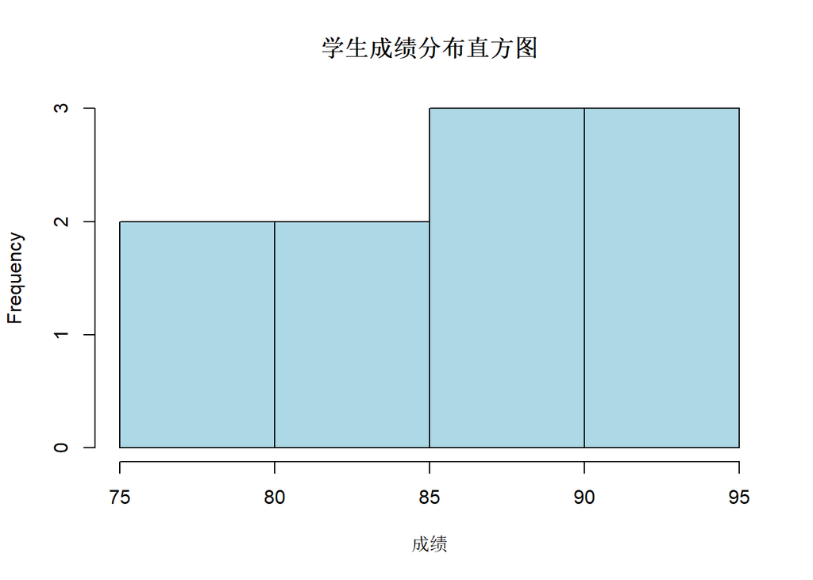

```r
# hist()函数绘制直方图，展示数值分布
# main参数设置标题，xlab参数设置x轴标签
hist(student_data$score,
     main = "学生成绩分布直方图",
     xlab = "成绩",
     col = "lightblue",
     breaks = 5)  # breaks设置分组数量
```

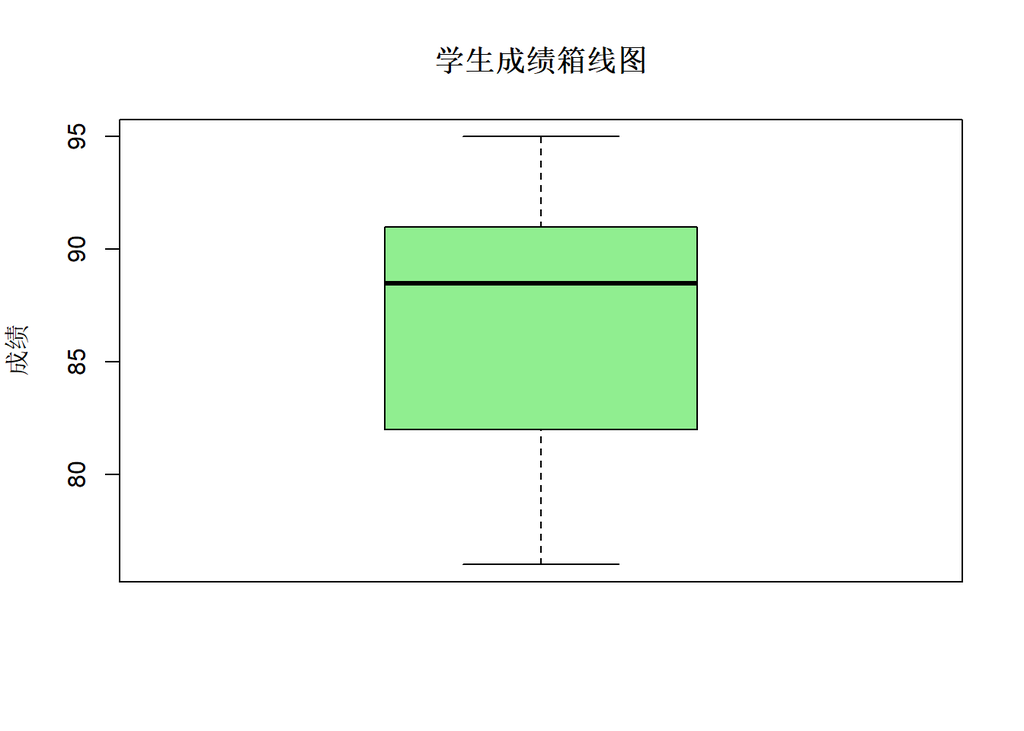

```r
# boxplot()函数绘制箱线图
# 可以直观展示中位数、四分位数和异常值
boxplot(student_data$score,
        main = "学生成绩箱线图",
        ylab = "成绩",
        col = "lightgreen")
```

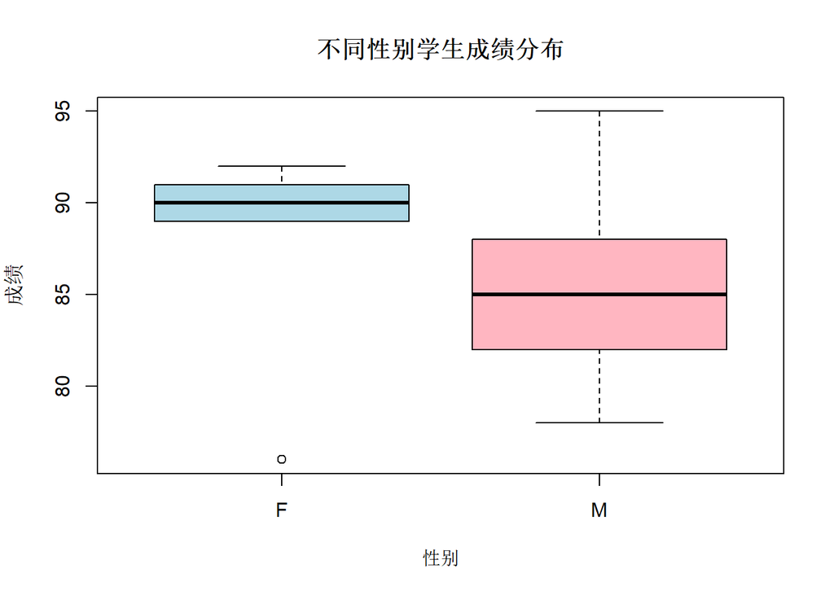

```r
# 按性别分组绘制箱线图
# 公式写法：y ~ group
boxplot(score ~ gender, data = student_data,
        main = "不同性别学生成绩分布",
        xlab = "性别",
        ylab = "成绩",
        col = c("lightblue", "lightpink"))
```

**小结**：直方图展示整体分布，箱线图展示分布特征和异常值，两者配合使用效果更好。

## 1.9 数据类型概览

了解每个变量的数据类型是数据处理的基础。

```r
# class()函数返回对象的类
class(student_data)        # 数据框类型
```

```
## [1] "data.frame"
```

```r
class(student_data$name)   # 字符型
```

```
## [1] "character"
```

```r
class(student_data$age)    # 数值型（整数）
```

```
## [1] "numeric"
```

```r
class(student_data$score)  # 数值型（实数）
```

```
## [1] "numeric"
```

```r
# typeof()函数返回对象在内存中的存储类型
# 比class()更底层
typeof(student_data$id)    # "integer"整数
```

```
## [1] "integer"
```

```r
typeof(student_data$score) # "double"双精度浮点数
```

```
## [1] "double"
```

```r
typeof(student_data$name)  # "character"字符
```

```
## [1] "character"
```

```r
# 查看所有列的类型
sapply(student_data, class)
```

```
##          id        name         age       score      gender
##   "integer" "character"   "numeric"   "numeric" "character"
```

**小结**：`class()`返回高级类型，`typeof()`返回底层存储类型，两者配合使用可以全面了解数据类型。

## 第一章总结

| 函数 | 用途 | 返回值 |
| --- | --- | --- |
| `dim()` | 查看维度 | 行数和列数 |
| `nrow()` | 查看行数 | 行数 |
| `ncol()` | 查看列数 | 列数 |
| `str()` | 查看结构 | 变量类型和前几值 |
| `glimpse()` | 查看结构（dplyr） | 紧凑的结构信息 |
| `names()` | 查看列名 | 列名向量 |
| `head()` | 查看前几行 | 前n行数据 |
| `tail()` | 查看后几行 | 后n行数据 |
| `summary()` | 摘要统计 | 统计摘要 |
| `is.na()` | 检测缺失值 | 逻辑矩阵 |
| `class()` | 查看类型 | 对象类 |
| `typeof()` | 查看存储类型 | 存储类型 |

# 第二章：缺失值处理

缺失值是现实数据中最常见的问题之一。正确处理缺失值对于保证分析结果的准确性至关重要。本章介绍缺失值的识别、统计和各种处理方法。

## 2.1 缺失值识别

首先，我们需要识别数据中的缺失值位置。

```r
# 创建一个包含多种缺失情况的示例数据
sales_data <- data.frame(
  product = c("A", "B", "C", "D", "E", "F", "G", "H"),
  price = c(100, NA, 200, 150, NA, 180, 220, NA),
  quantity = c(10, 20, NA, 15, 25, NA, 30, 12),
  revenue = c(1000, NA, NA, 2250, 3000, NA, 6600, NA)
)

# is.na()检测每个值是否为NA
# 返回逻辑向量，TRUE表示缺失
is.na(sales_data$price)
```

```
## [1] FALSE  TRUE FALSE FALSE  TRUE FALSE FALSE  TRUE
```

```r
# which()配合is.na()找出缺失值的位置索引
which(is.na(sales_data$price))
```

```
## [1] 2 5 8
```

```r
# complete.cases()函数识别完整的行（没有缺失值的行）
# 返回逻辑向量，TRUE表示该行完整
complete.cases(sales_data)
```

```
## [1]  TRUE FALSE FALSE  TRUE FALSE FALSE  TRUE FALSE
```

```r
# 查看完整的行
sales_data[complete.cases(sales_data), ]
```

```
##   product price quantity revenue
## 1       A   100       10    1000
## 4       D   150       15    2250
## 7       G   220       30    6600
```

```r
# 查看有缺失值的行
# 用感叹号取反
sales_data[!complete.cases(sales_data), ]
```

```
##   product price quantity revenue
## 2       B    NA       20      NA
## 3       C   200       NA      NA
## 5       E    NA       25    3000
## 6       F   180       NA      NA
## 8       H    NA       12      NA
```

**小结**：`is.na()`检测单个值，`complete.cases()`识别完整行，两者配合可以精确定位缺失值。

## 2.2 缺失值统计

了解缺失值的数量和比例，有助于决定处理策略。

```r
# 计算每列缺失值数量
colSums(is.na(sales_data))
```

```
##  product    price quantity  revenue
##        0        3        2        4
```

```r
# 计算每列缺失值比例
colSums(is.na(sales_data)) / nrow(sales_data)
```

```
##  product    price quantity  revenue
##    0.000    0.375    0.250    0.500
```

```r
# 计算每行缺失值数量
rowSums(is.na(sales_data))
```

```
## [1] 0 2 2 0 1 2 0 2
```

```r
# 计算总缺失值数量
sum(is.na(sales_data))
```

```
## [1] 9
```

```r
# 计算总缺失值比例
sum(is.na(sales_data)) / (nrow(sales_data) * ncol(sales_data))
```

```
## [1] 0.28125
```

```r
# 创建一个缺失值统计汇总表
missing_summary <- data.frame(
  variable = names(sales_data),
  missing_count = colSums(is.na(sales_data)),
  missing_percent = round(colSums(is.na(sales_data)) / nrow(sales_data) * 100, 2)
)
missing_summary
```

```
##          variable missing_count missing_percent
## product   product             0             0.0
## price       price             3            37.5
## quantity quantity             2            25.0
## revenue   revenue             4            50.0
```

**小结**：统计缺失值数量和比例，可以帮助判断哪些变量需要重点处理。

## 2.3 删除缺失值

当缺失值较少时，可以直接删除含有缺失值的行或列。

```r
# na.omit()函数删除含有缺失值的行
# 返回只包含完整行的数据框
na.omit(sales_data)
```

```
##   product price quantity revenue
## 1       A   100       10    1000
## 4       D   150       15    2250
## 7       G   220       30    6600
```

```r
# 使用dplyr包的drop_na()函数
# 功能更灵活，可以指定列
library(dplyr)

# 删除所有含有缺失值的行
drop_na(sales_data)
```

```
## drop_na: removed 5 rows (62%), 3 rows remaining
```

```
##   product price quantity revenue
## 1       A   100       10    1000
## 2       D   150       15    2250
## 3       G   220       30    6600
```

```r
# 只删除price列有缺失值的行
drop_na(sales_data, price)
```

```
## drop_na: removed 3 rows (38%), 5 rows remaining
```

```
##   product price quantity revenue
## 1       A   100       10    1000
## 2       C   200       NA      NA
## 3       D   150       15    2250
## 4       F   180       NA      NA
## 5       G   220       30    6600
```

```r
# 删除price和quantity列都有缺失值的行
drop_na(sales_data, c(price, quantity))
```

```
## drop_na: removed 5 rows (62%), 3 rows remaining
```

```
##   product price quantity revenue
## 1       A   100       10    1000
## 2       D   150       15    2250
## 3       G   220       30    6600
```

**小结**：`na.omit()`简单直接，`drop_na()`更灵活，可以根据需要选择使用。

## 2.4 删除全为缺失的行或列

有时数据中存在完全为空的行或列，需要清理。

```r
# 创建一个含有全空行和列的数据框
messy_data <- data.frame(
  x = c(1, NA, 3, NA),
  y = c(NA, NA, NA, NA),  # 全为NA的列
  z = c(5, 6, NA, 8)
)
messy_data <- rbind(messy_data, c(NA, NA, NA))  # 添加全为NA的行

# janitor包提供了便捷的清理函数
# 如果没有安装，先运行：install.packages("janitor")
library(janitor)

# remove_empty()删除全为NA的行和列
remove_empty(messy_data)
```

```
## value for "which" not specified, defaulting to c("rows", "cols")
```

```
##    x  z
## 1  1  5
## 2 NA  6
## 3  3 NA
## 4 NA  8
```

```r
# 只删除全为NA的列
remove_empty(messy_data, which = "cols")
```

```
##    x  z
## 1  1  5
## 2 NA  6
## 3  3 NA
## 4 NA  8
## 5 NA NA
```

```r
# 只删除全为NA的行
remove_empty(messy_data, which = "rows")
```

```
##    x  y  z
## 1  1 NA  5
## 2 NA NA  6
## 3  3 NA NA
## 4 NA NA  8
```

**小结**：`janitor::remove_empty()`可以快速清理空白行列，非常实用。

## 2.5 缺失值填补——均值/中位数/众数填补

当缺失值较多时，删除会损失大量信息，此时可以考虑填补。

```r
# 创建一个用于演示填补的数据
fill_data <- data.frame(
  id = 1:10,
  value = c(10, NA, 30, 25, NA, 35, 40, NA, 45, 50)
)

# 计算均值（忽略缺失值）
mean_value <- mean(fill_data$value, na.rm = TRUE)
mean_value
```

```
## [1] 33.57143
```

```r
# 用均值填补缺失值
fill_data$value_mean <- ifelse(
  is.na(fill_data$value),           # 条件：是否为缺失值
  mean_value,                        # 如果是，用均值填补
  fill_data$value                    # 如果不是，保持原值
)

# 用中位数填补
median_value <- median(fill_data$value, na.rm = TRUE)
fill_data$value_median <- ifelse(
  is.na(fill_data$value),
  median_value,
  fill_data$value
)

# 查看填补结果
fill_data
```

```
##    id value value_mean value_median
## 1   1    10   10.00000           10
## 2   2    NA   33.57143           35
## 3   3    30   30.00000           30
## 4   4    25   25.00000           25
## 5   5    NA   33.57143           35
## 6   6    35   35.00000           35
## 7   7    40   40.00000           40
## 8   8    NA   33.57143           35
## 9   9    45   45.00000           45
## 10 10    50   50.00000           50
```

```r
# 对于分类变量，可以用众数填补
# 创建一个含有缺失值的分类变量
category_data <- c("A", "B", "A", NA, "A", "B", NA, "A")

# 计算众数（出现次数最多的值）
# 使用table()统计频次
freq_table <- table(category_data, useNA = "ifany")
mode_value <- names(freq_table[which.max(freq_table)])
mode_value
```

```
## [1] "A"
```

```r
# 用众数填补
category_data_filled <- ifelse(is.na(category_data), mode_value, category_data)
category_data_filled
```

```
## [1] "A" "B" "A" "A" "A" "B" "A" "A"
```

**小结**：均值适合正态分布数据，中位数适合偏态分布，众数适合分类变量。

## 2.6 缺失值填补——前向/后向填补

时间序列数据中，常用前后值来填补缺失值。

```r
# 创建时间序列数据
time_data <- data.frame(
  day = 1:10,
  value = c(10, NA, NA, 40, 50, NA, 70, 80, NA, 100)
)

# 使用tidyr包的fill()函数进行前向/后向填补
library(tidyr)

# 前向填补：用前一个非缺失值填补
fill(time_data, value, .direction = "down")
```

```
## fill: changed 4 values (40%) of 'value' (4 fewer NAs)
```

```
##    day value
## 1    1    10
## 2    2    10
## 3    3    10
## 4    4    40
## 5    5    50
## 6    6    50
## 7    7    70
## 8    8    80
## 9    9    80
## 10  10   100
```

```r
# 后向填补：用后一个非缺失值填补
fill(time_data, value, .direction = "up")
```

```
## fill: changed 4 values (40%) of 'value' (4 fewer NAs)
```

```
##    day value
## 1    1    10
## 2    2    40
## 3    3    40
## 4    4    40
## 5    5    50
## 6    6    70
## 7    7    70
## 8    8    80
## 9    9   100
## 10  10   100
```

```r
# 双向填补：先向后再向前（或相反）
fill(time_data, value, .direction = "downup")
```

```
## fill: changed 4 values (40%) of 'value' (4 fewer NAs)
```

```
##    day value
## 1    1    10
## 2    2    10
## 3    3    10
## 4    4    40
## 5    5    50
## 6    6    50
## 7    7    70
## 8    8    80
## 9    9    80
## 10  10   100
```

**小结**：`fill()`函数简单易用，特别适合时间序列数据的缺失值填补。

## 2.7 缺失值填补——线性插值

对于连续型数据，线性插值是一种更精确的填补方法。

```r
# 使用approx()函数进行线性插值
# 创建一个包含缺失值的向量
x <- 1:10
y <- c(1, NA, NA, 4, 5, NA, 7, 8, NA, 10)

# approx()进行线性插值
# x参数是自变量，y参数是因变量
interp_result <- approx(x = x[!is.na(y)],    # 非缺失位置的x
                        y = y[!is.na(y)],    # 非缺失位置的y
                        xout = x)            # 需要插值的位置

# 查看插值结果
interp_result$y
```

```
##  [1]  1  2  3  4  5  6  7  8  9 10
```

```r
# zoo包提供了更便捷的插值函数
# 如果没有安装，先运行：install.packages("zoo")
library(zoo)

# na.approx()进行线性插值
na.approx(y)
```

```
##  [1]  1  2  3  4  5  6  7  8  9 10
```

```r
# na.spline()进行样条插值（更平滑）
na.spline(y)
```

```
##  [1]  1  2  3  4  5  6  7  8  9 10
```

**小结**：线性插值假设数据点之间呈线性关系，适合变化趋势平稳的数据。

## 2.8 缺失值填补——预测模型填补

当变量之间存在相关性时，可以用其他变量预测缺失值。

```r
# mice包（Multivariate Imputation by Chained Equations）
# 是最常用的多重插值包
# 如果没有安装，先运行：install.packages("mice")
library(mice)

# 创建示例数据
model_data <- data.frame(
  x1 = c(1, 2, 3, 4, 5, 6, 7, 8, 9, 10),
  x2 = c(2, 4, NA, 8, 10, 12, NA, 16, 18, 20),
  x3 = c(3, 6, 9, NA, 15, 18, 21, NA, 27, 30)
)

# 查看缺失模式
md.pattern(model_data)

# 使用mice进行多重插值
# m = 5 表示生成5个插值数据集
# method = "pmm" 表示预测均值匹配法
imp <- mice(model_data, m = 5, method = "pmm", seed = 123)

# 查看插值结果
imp$imp$x2  # x2变量的5次插值结果

# 获取完整的插值数据集（取第一个）
complete_data <- complete(imp, 1)
complete_data
```

[output not shown]

**小结**：`mice`包提供了多种插值方法，适合复杂数据的缺失值处理。

## 2.9 缺失值填补——KNN填补

K近邻填补使用相似样本的值来填补缺失值。

```r
# VIM包提供了kNN()函数
library(VIM)

# 创建示例数据
knn_data <- data.frame(
  a = c(1, 2, NA, 4, 5, 6, 7, 8),
  b = c(2, 4, 6, 8, 10, NA, 14, 16),
  c = c(3, 6, 9, 12, 15, 18, NA, 24)
)

# kNN填补
# k = 5 表示使用5个最近邻
knn_result <- kNN(knn_data, k = 5)

# 查看填补结果
knn_result
```

[output not shown]

**小结**：KNN填补基于相似性原理，适合样本之间有相似性的数据。

## 2.10 缺失值处理——虚拟变量指示

有时缺失本身可能包含信息，可以创建缺失指示变量。

```r
# 创建缺失指示变量
sales_data$price_missing <- as.integer(is.na(sales_data$price))
sales_data$quantity_missing <- as.integer(is.na(sales_data$quantity))

# 查看结果
sales_data
```

```
##   product price quantity revenue price_missing quantity_missing
## 1       A   100       10    1000             0                0
## 2       B    NA       20      NA             1                0
## 3       C   200       NA      NA             0                1
## 4       D   150       15    2250             0                0
## 5       E    NA       25    3000             1                0
## 6       F   180       NA      NA             0                1
## 7       G   220       30    6600             0                0
## 8       H    NA       12      NA             1                0
```

```r
# 使用dplyr批量创建缺失指示变量
library(dplyr)

sales_data %>%
  mutate(
    across(everything(),
           ~ as.integer(is.na(.)),
           .names = "{.col}_missing")
  )
```

```
## mutate: new variable 'product_missing' (integer) with one unique value and 0% NA
##         new variable 'revenue_missing' (integer) with 2 unique values and 0% NA
##         new variable 'price_missing_missing' (integer) with one unique value and 0% NA
##         new variable 'quantity_missing_missing' (integer) with one unique value and 0% NA
```

```
##   product price quantity revenue price_missing quantity_missing product_missing
## 1       A   100       10    1000             0                0               0
## 2       B    NA       20      NA             1                0               0
## 3       C   200       NA      NA             0                1               0
## 4       D   150       15    2250             0                0               0
## 5       E    NA       25    3000             1                0               0
## 6       F   180       NA      NA             0                1               0
## 7       G   220       30    6600             0                0               0
## 8       H    NA       12      NA             1                0               0
##   revenue_missing price_missing_missing quantity_missing_missing
## 1               0                     0                        0
## 2               1                     0                        0
## 3               1                     0                        0
## 4               0                     0                        0
## 5               0                     0                        0
## 6               1                     0                        0
## 7               0                     0                        0
## 8               1                     0                        0
```

**小结**：缺失指示变量可以捕捉”缺失”这一信息，在某些分析中很有价值。

## 第二章总结

| 方法 | 适用场景 | 优点 | 缺点 |
| --- | --- | --- | --- |
| 删除法 | 缺失比例小 | 简单直接 | 损失信息 |
| 均值/中位数填补 | 数值变量 | 保持样本量 | 降低方差 |
| 前向/后向填补 | 时间序列 | 保持时序性 | 不适合随机缺失 |
| 线性插值 | 连续变量 | 较精确 | 假设线性关系 |
| 预测模型填补 | 变量相关 | 利用变量关系 | 计算复杂 |
| KNN填补 | 样本相似 | 利用样本相似性 | 需要定义距离 |

# 第三章：重复值与异常值处理

数据质量直接影响分析结果的可靠性。本章介绍如何识别和处理重复值与异常值。

## 3.1 重复行识别

重复数据会导致分析结果偏差，需要识别并处理。

```r
# 创建包含重复行的数据
dup_data <- data.frame(
  id = c(1, 2, 3, 2, 4, 3, 5),
  name = c("A", "B", "C", "B", "D", "C", "E"),
  value = c(10, 20, 30, 20, 40, 30, 50)
)

# duplicated()函数识别重复行
# 返回逻辑向量，TRUE表示该行是重复的
duplicated(dup_data)
```

```
## [1] FALSE FALSE FALSE  TRUE FALSE  TRUE FALSE
```

```r
# 查看重复的行
dup_data[duplicated(dup_data), ]
```

```
##   id name value
## 4  2    B    20
## 6  3    C    30
```

```r
# 查看所有重复行（包括第一次出现的）
# 使用条件：该行出现次数大于1
dup_data[duplicated(dup_data) | duplicated(dup_data, fromLast = TRUE), ]
```

```
##   id name value
## 2  2    B    20
## 3  3    C    30
## 4  2    B    20
## 6  3    C    30
```

```r
# dplyr的distinct()识别唯一行
distinct(dup_data)
```

```
## distinct: removed 2 rows (29%), 5 rows remaining
```

```
##   id name value
## 1  1    A    10
## 2  2    B    20
## 3  3    C    30
## 4  4    D    40
## 5  5    E    50
```

**小结**：`duplicated()`标记重复行，`distinct()`直接返回唯一行。

## 3.2 删除重复行

识别重复行后，可以选择删除。

```r
# 使用unique()删除重复行
unique(dup_data)
```

```
##   id name value
## 1  1    A    10
## 2  2    B    20
## 3  3    C    30
## 5  4    D    40
## 7  5    E    50
```

```r
# 使用dplyr的distinct()删除重复行
distinct(dup_data)
```

```
## distinct: removed 2 rows (29%), 5 rows remaining
```

```
##   id name value
## 1  1    A    10
## 2  2    B    20
## 3  3    C    30
## 4  4    D    40
## 5  5    E    50
```

```r
# distinct()可以指定列来判断重复
# 只根据id和name判断重复
distinct(dup_data, id, name, .keep_all = TRUE)
```

```
## distinct: removed 2 rows (29%), 5 rows remaining
```

```
##   id name value
## 1  1    A    10
## 2  2    B    20
## 3  3    C    30
## 4  4    D    40
## 5  5    E    50
```

**小结**：`unique()`简单直接，`distinct()`更灵活，可以指定判断重复的列。

## 3.3 基于特定列的去重

有时只需要根据特定列判断重复。

```r
# 创建数据：id相同但其他列不同
partial_dup <- data.frame(
  id = c(1, 1, 2, 2, 3),
  name = c("A", "A", "B", "B2", "C"),
  value = c(10, 20, 30, 40, 50)
)

# 根据id去重，保留第一个出现的
distinct(partial_dup, id, .keep_all = TRUE)
```

```
## distinct: removed 2 rows (40%), 3 rows remaining
```

```
##   id name value
## 1  1    A    10
## 2  2    B    30
## 3  3    C    50
```

```r
# 根据id和name去重
distinct(partial_dup, id, name, .keep_all = TRUE)
```

```
## distinct: removed one row (20%), 4 rows remaining
```

```
##   id name value
## 1  1    A    10
## 2  2    B    30
## 3  2   B2    40
## 4  3    C    50
```

```r
# 使用duplicated()基于特定列
partial_dup[!duplicated(partial_dup$id), ]
```

```
##   id name value
## 1  1    A    10
## 3  2    B    30
## 5  3    C    50
```

**小结**：基于特定列去重时，要注意保留哪一条记录。

## 3.4 异常值识别——基于统计量

异常值检测是数据分析的重要环节。

```r
# 创建包含异常值的数据
outlier_data <- c(10, 12, 11, 13, 10, 100, 11, 12, -50, 14, 11, 13)

# 方法1：Z-score方法
# Z-score = (x - mean) / sd
# 通常|Z| > 3被认为是异常值
z_scores <- (outlier_data - mean(outlier_data)) / sd(outlier_data)
abs(z_scores) > 3  # 标记异常值
```

```
##  [1] FALSE FALSE FALSE FALSE FALSE FALSE FALSE FALSE FALSE FALSE FALSE FALSE
```

```r
# 查看被标记为异常值的点
outlier_data[abs(z_scores) > 3]
```

```
## numeric(0)
```

```r
# 方法2：IQR方法（四分位距方法）
# IQR = Q3 - Q1
# 异常值定义：小于Q1-1.5*IQR 或 大于Q3+1.5*IQR
Q1 <- quantile(outlier_data, 0.25)
Q3 <- quantile(outlier_data, 0.75)
IQR_value <- Q3 - Q1

lower_bound <- Q1 - 1.5 * IQR_value
upper_bound <- Q3 + 1.5 * IQR_value

# 识别异常值
outlier_data < lower_bound | outlier_data > upper_bound
```

```
##  [1] FALSE FALSE FALSE FALSE FALSE  TRUE FALSE FALSE  TRUE FALSE FALSE FALSE
```

```r
# 查看异常值
outlier_data[outlier_data < lower_bound | outlier_data > upper_bound]
```

```
## [1] 100 -50
```

**小结**：Z-score适合正态分布，IQR方法对非正态分布更稳健。

## 3.5 异常值识别——可视化方法

可视化是识别异常值的直观方法。

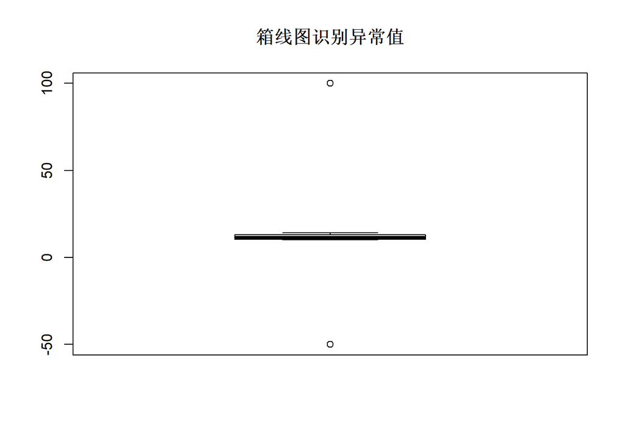

```r
# 箱线图识别异常值
# 箱线图自动标记超出1.5*IQR范围的点
boxplot(outlier_data, main = "箱线图识别异常值")
```

```r
# 获取箱线图识别的异常值
boxplot_stats <- boxplot.stats(outlier_data)
boxplot_stats$out  # 异常值
```

```
## [1] 100 -50
```

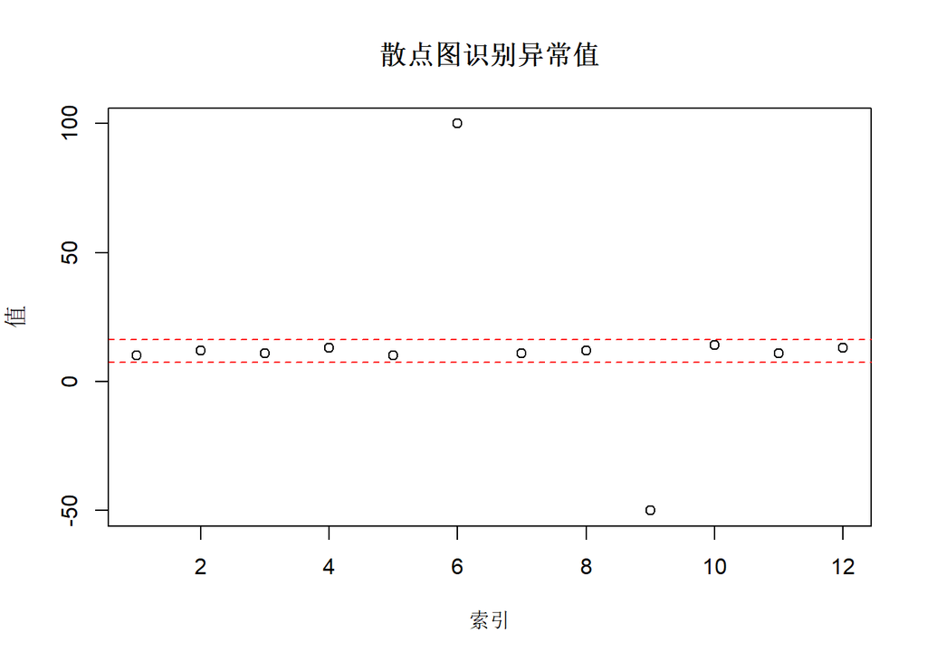

```r
# 散点图识别异常值
plot(outlier_data, main = "散点图识别异常值",
     xlab = "索引", ylab = "值")
abline(h = upper_bound, col = "red", lty = 2)  # 上边界
abline(h = lower_bound, col = "red", lty = 2)  # 下边界
```

**小结**：箱线图是最常用的异常值可视化方法，直观且自动计算边界。